# LeetCode Recommender Simulation Analysis

This notebook analyzes the results from simulating different agent profiles (Beginner, Moderate, Expert) interacting with the LeetCode recommender system versus a random baseline.

# 1. Setup: Import libraries and define basic parameters

```python
import pandas as pd
import numpy as np
import matplotlib.pyplot as plt
import seaborn as sns
import os
import glob
```

```python
sns.set(style="whitegrid")
plt.rcParams['figure.figsize'] = (12, 6) # Default figure size

# Define base directory and file pattern
LOG_DIR = '.' # Assuming logs are in the same directory as the notebook
FILE_PATTERN = 'simulation_log_*.csv'

# Define known profiles and types for ordering/coloring plots
PROFILES = ['Beginner', 'Moderate', 'Expert']
AGENT_TYPES = ['recommender', 'random_baseline']

try:
    # If simulation.py is in the same directory or path
    from simulation import AGENT_CATEGORIES
    SKILL_COLS = [f'agent_skill_{cat.replace(" ", "_")}' for cat in AGENT_CATEGORIES]
except ImportError:
    print("Warning: Could not import AGENT_CATEGORIES. Manually define or ensure simulation.py is accessible.")
    # Manually define if needed, ensure it matches the columns in your CSV
    AGENT_CATEGORIES = [
        "Arrays and Hashing", "Two Pointers", "Stack", "Sliding Window", "Binary Search",
        "Linked List", "Tree", "Tries", "Heap / Priority Queue", "Backtracking",
        "Intervals", "Greedy", "Graph", "Graph2", "1DDP", "2DDP",
        "Bit Manipulation", "Math"
    ] # Make sure this list matches your actual categories used in logging
    SKILL_COLS = [f'agent_skill_{cat.replace(" ", "_")}' for cat in AGENT_CATEGORIES]
```

## 2. Load Data

Find all simulation log files and combine them into a single DataFrame.

```python
all_files = glob.glob(os.path.join(LOG_DIR, FILE_PATTERN))

if not all_files:
    print(f"Error: No files found matching pattern '{FILE_PATTERN}' in directory '{LOG_DIR}'")
    # Stop execution or handle appropriately
    raise FileNotFoundError("No simulation log files found.")

li = []
for filename in all_files:
    print(f"Loading: {filename}")
    try:
        df_temp = pd.read_csv(filename)
        # Add filename parts as columns if not present (e.g., if run_all_simulations didn't exist yet)
        if 'agent_profile' not in df_temp.columns:
             # Example: Extract from filename 'simulation_log_Beginner_recommender.csv'
             parts = os.path.basename(filename).replace('simulation_log_', '').replace('.csv', '').split('_')
             if len(parts) >= 2:
                 df_temp['agent_profile'] = parts[0]
                 df_temp['agent_type'] = "_".join(parts[1:]) # Handle multi-word types if needed
        li.append(df_temp)
    except Exception as e:
        print(f"Error loading {filename}: {e}")


if not li:
     raise ValueError("No data loaded successfully.")

df = pd.concat(li, axis=0, ignore_index=True)

print(f"\nLoaded data shape: {df.shape}")
print("\nData types:")
print(df.dtypes)
print("\nFirst 5 rows:")
print(df.head())
print("\nAgent Profiles and Types Found:")
print(df[['agent_profile', 'agent_type']].value_counts())
```

```
Loading: ./simulation_log_Beginner_recommender.csv
Loading: ./simulation_log_Beginner_random.csv
Loading: ./simulation_log_Expert_recommender.csv
Loading: ./simulation_log_Moderate_recommender.csv
Loading: ./simulation_log_Moderate_random.csv
Loading: ./simulation_log_Expert_random.csv

Loaded data shape: (1200, 51)

Data types:
step                                          int64
agent_id                                      int64
agent_profile                                object
agent_type                                   object
problem_id                                    int64
problem_title                                object
problem_category                             object
problem_difficulty                           object
agent_skill_before                          float64
solved                                         bool
time_taken                                  float64
agent_skill_after                           float64
recommender_reward                          float64
interleaving_factor                         float64
total_attempts_recommender                    int64
agent_skill_Arrays_and_Hashing              float64
agent_skill_Two_Pointers                    float64
agent_skill_Stack                           float64
agent_skill_Sliding_Window                  float64
agent_skill_Binary_Search                   float64
agent_skill_Linked_List                     float64
agent_skill_Tree                            float64
agent_skill_Tries                           float64
agent_skill_Heap_/_Priority_Queue           float64
agent_skill_Backtracking                    float64
agent_skill_Intervals                       float64
agent_skill_Greedy                          float64
agent_skill_Graph                           float64
agent_skill_Graph2                          float64
agent_skill_1DDP                            float64
```

[output cut: 69 more lines]

```
2                                  1.0                      1.0
3                                  1.0                      1.0
4                                  1.0                      1.0

[5 rows x 51 columns]

Agent Profiles and Types Found:
agent_profile  agent_type
Beginner       random_baseline    200
               recommender        200
Expert         random_baseline    200
               recommender        200
Moderate       random_baseline    200
               recommender        200
Name: count, dtype: int64
```

## 3. Data Cleaning / Preparation

- Convert columns to appropriate types if needed.
- Calculate average skill across all categories for each step.
- Calculate cumulative problems solved.

```python
if df['solved'].dtype != bool:
    df['solved'] = df['solved'].astype(bool)

# Calculate average agent skill per row
# Ensure all skill columns exist before attempting to calculate mean
existing_skill_cols = [col for col in SKILL_COLS if col in df.columns]
if not existing_skill_cols:
     print("Warning: No skill columns found in the DataFrame. Skipping average skill calculation.")
     df['average_skill'] = np.nan
else:
     if len(existing_skill_cols) < len(SKILL_COLS):
          print(f"Warning: Missing some skill columns. Calculating average based on found columns: {existing_skill_cols}")
     df['average_skill'] = df[existing_skill_cols].mean(axis=1)

# Calculate cumulative solved count per agent run
# Group by agent_id, profile, type and then calculate cumulative sum on 'solved'
df['cumulative_solved'] = df.sort_values(by='step').groupby(['agent_id', 'agent_profile', 'agent_type'])['solved'].cumsum()

print("\nDataFrame with calculated columns:")
print(df[['step', 'agent_profile', 'agent_type', 'solved', 'average_skill', 'cumulative_solved']].head())
```

```
DataFrame with calculated columns:
   step agent_profile   agent_type  solved  average_skill  cumulative_solved
0     1      Beginner  recommender   False       0.100000                  0
1     2      Beginner  recommender   False       0.100000                  0
2     3      Beginner  recommender   False       0.100000                  0
3     4      Beginner  recommender    True       0.102778                  1
4     5      Beginner  recommender   False       0.102778                  1
```

## 4. Analysis & Visualization

### 4.1 Overall Performance Comparison

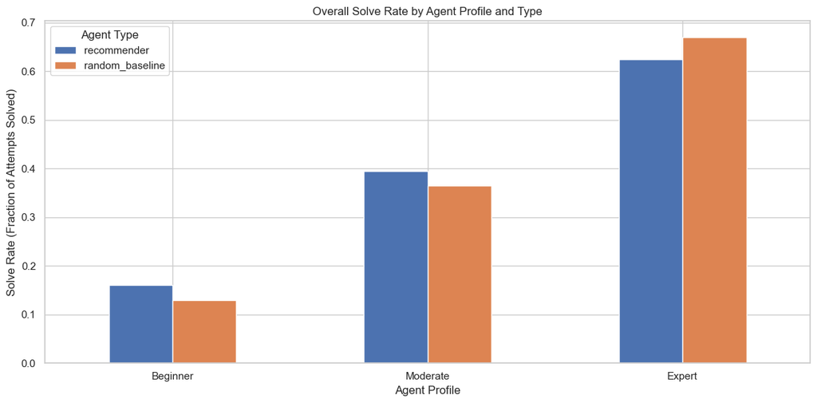

```python
plt.figure(figsize=(10, 6))
solve_rate_summary = df.groupby(['agent_profile', 'agent_type'])['solved'].mean().unstack()
solve_rate_summary = solve_rate_summary.reindex(index=PROFILES, columns=AGENT_TYPES) # Ensure consistent order
solve_rate_summary.plot(kind='bar', rot=0)
plt.title('Overall Solve Rate by Agent Profile and Type')
plt.ylabel('Solve Rate (Fraction of Attempts Solved)')
plt.xlabel('Agent Profile')
plt.legend(title='Agent Type')
plt.tight_layout()
plt.show()
```

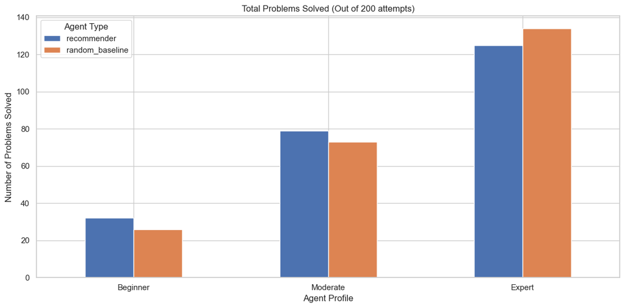

```python
plt.figure(figsize=(10, 6))
total_solved_summary = df.groupby(['agent_profile', 'agent_type'])['solved'].sum().unstack()
total_solved_summary = total_solved_summary.reindex(index=PROFILES, columns=AGENT_TYPES)
total_solved_summary.plot(kind='bar', rot=0)
plt.title(f'Total Problems Solved (Out of {df["step"].max()} attempts)')
plt.ylabel('Number of Problems Solved')
plt.xlabel('Agent Profile')
plt.legend(title='Agent Type')
plt.tight_layout()
plt.show()
```

### 4.2 Learning Progression

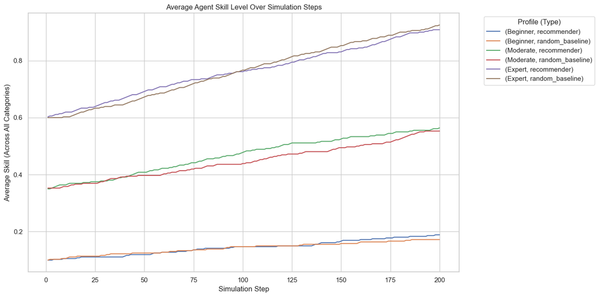

```python
# Average Skill Level Over Time
plt.figure(figsize=(14, 7))
avg_skill_over_time = df.groupby(['step', 'agent_profile', 'agent_type'])['average_skill'].mean().unstack(['agent_profile', 'agent_type'])
# Reorder columns for better legend readability
avg_skill_over_time = avg_skill_over_time.reindex(columns=pd.MultiIndex.from_product([PROFILES, AGENT_TYPES], names=['agent_profile', 'agent_type']))

avg_skill_over_time.plot(ax=plt.gca()) # Plot on the current axes
plt.title('Average Agent Skill Level Over Simulation Steps')
plt.ylabel('Average Skill (Across All Categories)')
plt.xlabel('Simulation Step')
plt.legend(title='Profile (Type)', bbox_to_anchor=(1.05, 1), loc='upper left')
plt.tight_layout()
plt.show()
```

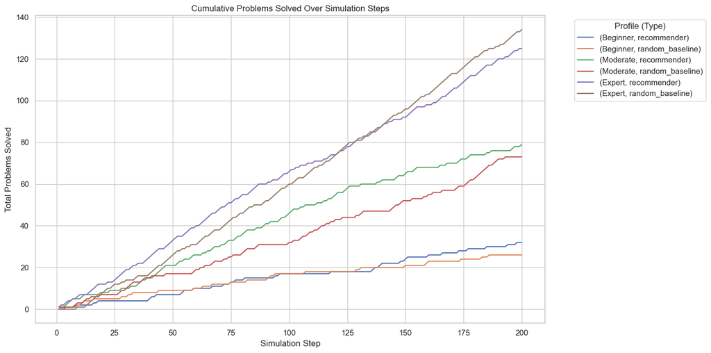

```python
plt.figure(figsize=(14, 7))
cumulative_solved_over_time = df.groupby(['step', 'agent_profile', 'agent_type'])['cumulative_solved'].mean().unstack(['agent_profile', 'agent_type'])
cumulative_solved_over_time = cumulative_solved_over_time.reindex(columns=pd.MultiIndex.from_product([PROFILES, AGENT_TYPES], names=['agent_profile', 'agent_type']))

cumulative_solved_over_time.plot(ax=plt.gca())
plt.title('Cumulative Problems Solved Over Simulation Steps')
plt.ylabel('Total Problems Solved')
plt.xlabel('Simulation Step')
plt.legend(title='Profile (Type)', bbox_to_anchor=(1.05, 1), loc='upper left')
plt.tight_layout()
plt.show()
```

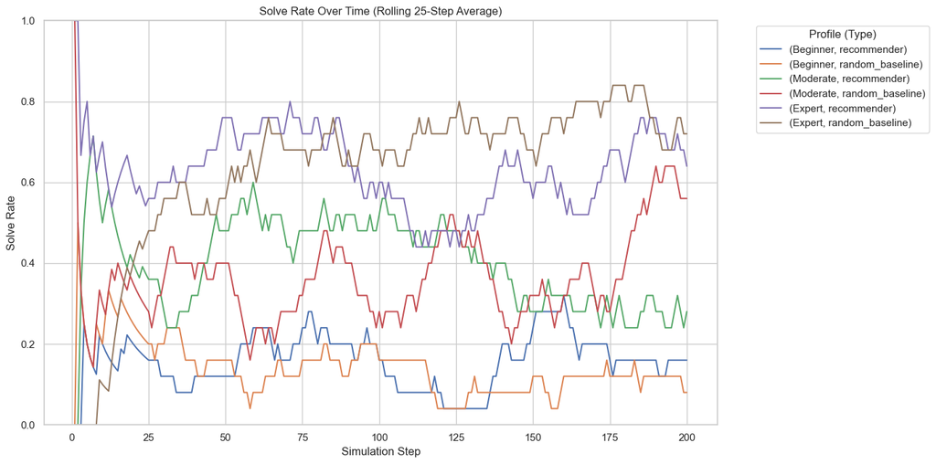

```python
WINDOW_SIZE = 25 # Adjust as needed
df['solve_rate_rolling'] = df.sort_values(by='step').groupby(['agent_id', 'agent_profile', 'agent_type'])['solved'] \
                             .rolling(window=WINDOW_SIZE, min_periods=1).mean().reset_index(level=[0,1,2], drop=True)

plt.figure(figsize=(14, 7))
rolling_solve_rate = df.groupby(['step', 'agent_profile', 'agent_type'])['solve_rate_rolling'].mean().unstack(['agent_profile', 'agent_type'])
rolling_solve_rate = rolling_solve_rate.reindex(columns=pd.MultiIndex.from_product([PROFILES, AGENT_TYPES], names=['agent_profile', 'agent_type']))

rolling_solve_rate.plot(ax=plt.gca())
plt.title(f'Solve Rate Over Time (Rolling {WINDOW_SIZE}-Step Average)')
plt.ylabel('Solve Rate')
plt.xlabel('Simulation Step')
plt.ylim(0, 1) # Rate is between 0 and 1
plt.legend(title='Profile (Type)', bbox_to_anchor=(1.05, 1), loc='upper left')
plt.tight_layout()
plt.show()
```

### 4.3 Problem Selection Patterns

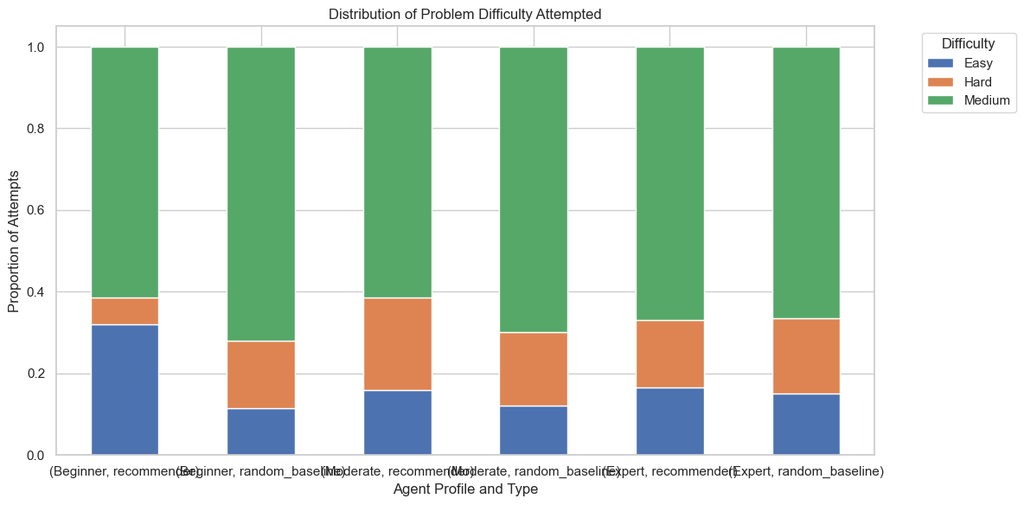

```python
# Distribution of Problem Difficulty Attempted
plt.figure(figsize=(12, 7))
difficulty_counts = pd.crosstab([df['agent_profile'], df['agent_type']], df['problem_difficulty'], normalize='index')
difficulty_counts = difficulty_counts.reindex(index=pd.MultiIndex.from_product([PROFILES, AGENT_TYPES], names=['agent_profile', 'agent_type']))

difficulty_counts.plot(kind='bar', stacked=True, rot=0)
plt.title('Distribution of Problem Difficulty Attempted')
plt.ylabel('Proportion of Attempts')
plt.xlabel('Agent Profile and Type')
plt.legend(title='Difficulty', bbox_to_anchor=(1.05, 1), loc='upper left')
plt.tight_layout()
plt.show()
```

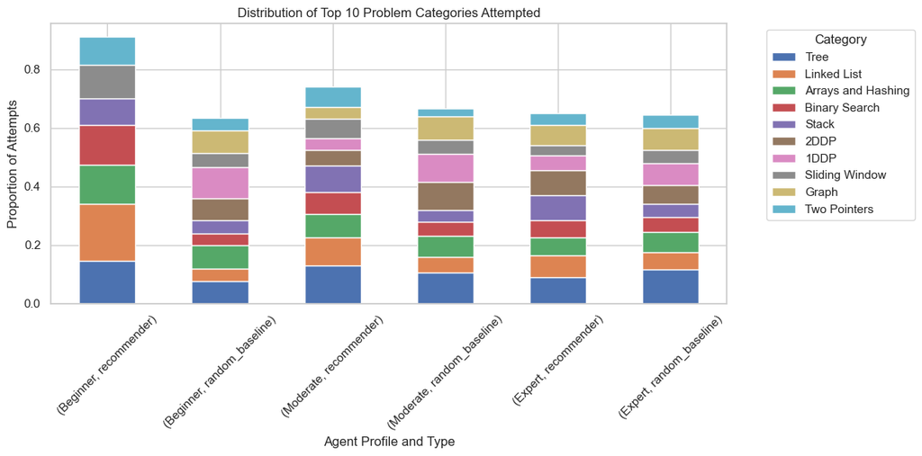

```
Full Category Distribution (Proportions):
problem_category                1DDP   2DDP  Arrays and Hashing  Backtracking  \
agent_profile agent_type
Beginner      recommender      0.000  0.000               0.135         0.000
              random_baseline  0.105  0.075               0.080         0.065
Moderate      recommender      0.040  0.055               0.080         0.035
              random_baseline  0.095  0.095               0.070         0.050
Expert        recommender      0.050  0.085               0.060         0.065
              random_baseline  0.075  0.065               0.070         0.065

problem_category               Binary Search  Bit Manipulation  Graph  Graph2  \
agent_profile agent_type
Beginner      recommender              0.135             0.000  0.000   0.000
              random_baseline          0.040             0.025  0.075   0.060
Moderate      recommender              0.075             0.015  0.040   0.035
              random_baseline          0.050             0.025  0.080   0.050
Expert        recommender              0.060             0.040  0.070   0.060
              random_baseline          0.050             0.035  0.075   0.030

problem_category               Greedy  Heap / Priority Queue  Intervals  \
agent_profile agent_type
Beginner      recommender       0.000                  0.000      0.000
              random_baseline   0.050                  0.050      0.040
Moderate      recommender       0.020                  0.040      0.020
              random_baseline   0.060                  0.035      0.050
Expert        recommender       0.040                  0.025      0.030
              random_baseline   0.045                  0.055      0.045

problem_category               Linked List   Math  Sliding Window  Stack  \
agent_profile agent_type
Beginner      recommender            0.195  0.000           0.115  0.090
              random_baseline        0.045  0.060           0.050  0.045
Moderate      recommender            0.095  0.025           0.065  0.090
              random_baseline        0.055  0.030           0.050  0.040
Expert        recommender            0.075  0.070           0.035  0.085
              random_baseline        0.060  0.060           0.045  0.045

problem_category                Tree  Tries  Two Pointers
agent_profile agent_type
Beginner      recommender      0.145  0.090         0.095
              random_baseline  0.075  0.015         0.045
Moderate      recommender      0.130  0.070         0.070
              random_baseline  0.105  0.035         0.025
Expert        recommender      0.090  0.020         0.040
              random_baseline  0.115  0.020         0.045
```

```python
# Distribution of Problem Categories Attempted (May be too cluttered - consider top N or grouping)
plt.figure(figsize=(15, 8))
# Use normalize='index' for proportion within each agent group
category_counts = pd.crosstab([df['agent_profile'], df['agent_type']], df['problem_category'], normalize='index')
category_counts = category_counts.reindex(index=pd.MultiIndex.from_product([PROFILES, AGENT_TYPES], names=['agent_profile', 'agent_type']))

# Plotting all categories might be too much, consider plotting top N or just showing the table
# Example: Plot top 10 most attempted categories overall
top_categories = df['problem_category'].value_counts().nlargest(10).index
category_counts[top_categories].plot(kind='bar', stacked=True, rot=45) # Use rot=45 for readability
plt.title('Distribution of Top 10 Problem Categories Attempted')
plt.ylabel('Proportion of Attempts')
plt.xlabel('Agent Profile and Type')
plt.legend(title='Category', bbox_to_anchor=(1.05, 1), loc='upper left')
plt.tight_layout()
plt.show()

print("\nFull Category Distribution (Proportions):")
print(category_counts)
```

## Conclusions

- **Beginner & Moderate Agents:** The recommender shows a **slight advantage** over the random baseline in terms of both solve rate and total problems solved, leading to slightly higher final skill levels and skill gain.
- **Expert Agents:** Surprisingly, the **random baseline outperformed the recommender** in solve rate, total problems solved, and overall skill gain.
- **Problem Selection:** The recommender tends to select more Easy problems for Beginners and slightly more Hard problems for Moderates compared to random. For Experts, the difficulty distribution selected by the recommender is very similar to the random baseline.

**Detailed Analysis per Profile:**

1. **Beginner Profile:**
   - **Performance:** Recommender (16.0% solve rate, 32 solved) vs. Random (13.0%, 26 solved). The recommender provides a modest improvement.
   - **Skill:** Recommender (+0.089 gain) vs. Random (+0.072 gain). Consistent slight advantage for the recommender.
   - **Difficulty:** Recommender heavily favored Easy (32.0%) and Medium (61.5%), largely avoiding Hard (6.5%). Random was dominated by Medium (72.0%) and gave more Hard (16.5%) than the recommender.
   - *Interpretation:* The recommender successfully identified the Beginner's need for easier problems and steered them towards more Easy questions than random chance would provide, leading to better outcomes.
2. **Moderate Profile:**
   - **Performance:** Recommender (39.5% solve rate, 79 solved) vs. Random (36.5%, 73 solved). Again, a modest improvement for the recommender.
   - **Skill:** Recommender (+0.214 gain) vs. Random (+0.203 gain). Consistent slight advantage.
   - **Difficulty:** Recommender gave a more balanced mix (16.0% Easy, 61.5% Medium, 22.5% Hard) compared to Random (12.0% Easy, 70.0% Medium, 18.0% Hard).
   - *Interpretation:* The recommender provided a slightly better mix, including more Hard problems than random, which seems appropriate for a moderate user and resulted in slightly better learning.
3. **Expert Profile:**
   - **Performance:** Recommender (62.5% solve rate, 125 solved) vs. Random (67.0%, 134 solved). **Random performed better.**
   - **Skill:** Recommender (+0.308 gain) vs. Random (+0.325 gain). **Random led to slightly higher skill gain.**
   - **Difficulty:** The distributions were remarkably similar: Recommender (16.5% Easy, 67.0% Medium, 16.5% Hard) vs. Random (15.0% Easy, 66.5% Medium, 18.5% Hard).
   - *Interpretation:* This is the most interesting result. The recommender did *not* significantly alter the difficulty mix compared to random for the expert. Both systems heavily presented Medium problems. Because the recommender didn't push significantly more Hard problems (where the Expert likely has the most room to grow or maintain high skill), it failed to provide an advantage. The slight edge for random could be due to chance (randomly picking slightly more suitable problems within the Medium/Hard brackets) or potentially the recommender getting stuck recommending slightly suboptimal problems based on its reward history. The recommender isn't adequately challenging the expert.

**Key Takeaways & Potential Issues:**

1. **Marginal Benefit for Lower Levels:** The recommender provides a small, positive benefit for Beginners and Moderates primarily by adjusting the difficulty mix away from the database's likely Medium-heavy distribution.
2. **Failure at Expert Level:** The recommender does not seem optimized for high-skill users. It fails to identify that Experts need more challenging (Hard) problems and essentially defaults to a near-random distribution, resulting in worse performance.
3. **Difficulty Targeting:** The recommender's strength seems to be in coarse difficulty adjustment (more Easy for low skill), but it might not be effectively pushing users towards harder content within categories once they achieve moderate skill, especially experts.
4. **Recommender Tuning:** The internal mechanisms (epsilon-greedy exploration, interleaving factor, reward calculation, SM-2 interaction) might need tuning. Perhaps `EPSILON` needs to be higher, or `INTERLEAVING_FACTOR` needs to increase more aggressively, or the reward system doesn't properly incentivize tackling harder problems once easier ones in a category are mastered. The logic in `sm_2` might also be too conservative about picking Hard problems if Medium ones are available.

**Recommendations for Improvement:**

1. **Improve Expert Targeting:** Modify the recommendation logic (likely within `sm_2` or potentially `interleaving`/`epsilon_greedy`) to more aggressively select Hard problems for users with high overall skill or high skill in specific categories (perhaps by checking the agent's *actual* skill level if available, or by biasing towards Hard in `sm_2` if many Medium problems in the category are already solved/reviewed).
2. **Review Reward/Exploration:** Ensure the reward system and exploration (`EPSILON`, `INTERLEAVING_FACTOR`) don't prematurely converge or discourage tackling harder problems. Maybe the reward for solving a Hard problem should be significantly higher?
3. **Analyze Problem Choices:** Dig deeper into *which specific* problems are being recommended vs. chosen randomly, especially for Experts. Is the recommender repeatedly suggesting the same few reviewed problems instead of new, harder ones?
4. **Run More Simulations:** Increase `NUM_SIMULATION_STEPS` or run multiple trials per configuration to ensure these results are consistent and not just due to random chance in a single run.

Overall, the recommender shows some promise but needs significant refinement, particularly in how it handles and challenges high-skill users.